# E-News Express

#### E-News Express, a news website, wants to expand acquiring new subscribers. Each visitor to the website takes actions based upon their interest. The company wants analyze the interests of potential subscribers to determine whether or not a new feature will be effective. Companies sometimes analyze user responses to two variations of a product to decide which variation is more effective. This technique, known as a/b testing, is used to decide if a new feature is attractive to users based on a chosen metric.

#### The design team of the company has created a new landing page, and they want to know if it is effective to obtain new subscribers. 100 users were randomly selected and divided into two groups - the "control" group was shown the old landing page, while the "treatment" group was shown the new landing page. Various data was collected in order to perform statistical analysis and answer the following questions:

- Do users spend more time on the new landing page?
- Is the conversion rate (the proportion of users who visit the landing page and subscribe) greater for the new landing page or the old landing page?
- Does converted status depend on preferred language?
- Is the mean time spent on the new page the same for different language users?

Import necessary libraries, read in the data, and look at the first 15 rows

```python
import warnings
warnings.filterwarnings('ignore')
```

```python
import numpy as np
import pandas as pd
import matplotlib.pyplot as plt
import seaborn as sns

%matplotlib inline

import scipy.stats as stats
```

```python
abtest = pd.read_csv('abtest.csv')
abtest.head(15)
```

|  | user_id | group | landing_page | time_spent_on_the_page | converted | language_preferred |
| --- | --- | --- | --- | --- | --- | --- |
| 0 | 546592 | control | old | 3.48 | no | Spanish |
| 1 | 546468 | treatment | new | 7.13 | yes | English |
| 2 | 546462 | treatment | new | 4.40 | no | Spanish |
| 3 | 546567 | control | old | 3.02 | no | French |
| 4 | 546459 | treatment | new | 4.75 | yes | Spanish |
| 5 | 546558 | control | old | 5.28 | yes | English |
| 6 | 546448 | treatment | new | 5.25 | yes | French |
| 7 | 546581 | control | old | 6.53 | yes | Spanish |
| 8 | 546461 | treatment | new | 10.71 | yes | French |
| 9 | 546548 | control | old | 2.08 | no | English |
| 10 | 546588 | control | old | 6.21 | yes | Spanish |
| 11 | 546546 | control | old | 2.58 | yes | English |
| 12 | 546491 | treatment | new | 5.86 | yes | Spanish |
| 13 | 546478 | treatment | new | 6.03 | yes | French |
| 14 | 546578 | control | old | 8.72 | yes | Spanish |

Observations

- "user_id" is an identifier unique to each user
- "group" tells whether the user was in the control group or the treatment group
- "landing_page" tells which landing page the user was shown - old or new
- "time_spent_on_the_page" tells the time, in minutes, each user spent on the page
- "converted" tells whether or not the user subscribed to the news service - yes or no
- "language_preferred" tells what language the user prefers. So far, I see French, English and Spanish. I will find out if there are more later.

```python
#next, I will analyze the shape and data types of the dataframe, as well as check for missing values
abtest.shape
```

```
(100, 6)
```

```python
#100 rows, 6 columns
abtest.info()
```

```
<class 'pandas.core.frame.DataFrame'>
RangeIndex: 100 entries, 0 to 99
Data columns (total 6 columns):
 #   Column                  Non-Null Count  Dtype
---  ------                  --------------  -----
 0   user_id                 100 non-null    int64
 1   group                   100 non-null    object
 2   landing_page            100 non-null    object
 3   time_spent_on_the_page  100 non-null    float64
 4   converted               100 non-null    object
 5   language_preferred      100 non-null    object
dtypes: float64(1), int64(1), object(4)
memory usage: 4.8+ KB
```

```python
#Four columns of type "object" will need to be changed to "categorical".  No missing data, but just to be sure
abtest.isna().sum()
```

```
user_id                   0
group                     0
landing_page              0
time_spent_on_the_page    0
converted                 0
language_preferred        0
dtype: int64
```

```python
#Confirmed: no missing data.
abtest['group'] = abtest.group.astype('category')
abtest['landing_page'] = abtest.landing_page.astype('category')
abtest['converted'] = abtest.converted.astype('category')
abtest['language_preferred'] = abtest.language_preferred.astype('category')
abtest.info()
```

```
<class 'pandas.core.frame.DataFrame'>
RangeIndex: 100 entries, 0 to 99
Data columns (total 6 columns):
 #   Column                  Non-Null Count  Dtype
---  ------                  --------------  -----
 0   user_id                 100 non-null    int64
 1   group                   100 non-null    category
 2   landing_page            100 non-null    category
 3   time_spent_on_the_page  100 non-null    float64
 4   converted               100 non-null    category
 5   language_preferred      100 non-null    category
dtypes: category(4), float64(1), int64(1)
memory usage: 2.5 KB
```

```python
#Data types are fixed.  Next, I will see how many different languages are preferred by the users.
abtest.language_preferred.value_counts()
```

```
Spanish    34
French     34
English    32
Name: language_preferred, dtype: int64
```

```python
#Next, I will begin preliminary analysis on the time_spent_on_page column using describe
abtest.time_spent_on_the_page.describe()
```

```
count    100.000000
mean       5.377800
std        2.378166
min        0.190000
25%        3.880000
50%        5.415000
75%        7.022500
max       10.710000
Name: time_spent_on_the_page, dtype: float64
```

# EDA

### Univariate

##### Visualization of time spent on page

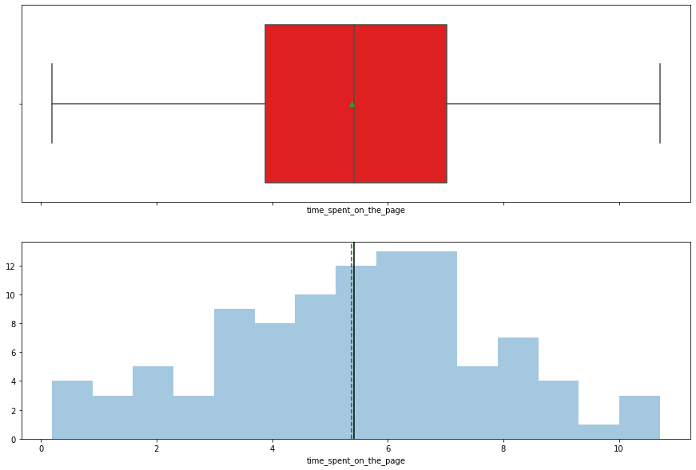

```python
#Creating a combination of histogram and boxplot
f2, (ax_box2, ax_hist2) = plt.subplots(nrows = 2, sharex = True, figsize=(15,10))
sns.boxplot(abtest.time_spent_on_the_page, ax=ax_box2, showmeans=True, color='red')
sns.distplot(abtest.time_spent_on_the_page, kde=False, ax=ax_hist2, bins=15)
ax_hist2.axvline(np.mean(abtest.time_spent_on_the_page), color='g', linestyle='--') # Add mean to the histogram
ax_hist2.axvline(np.median(abtest.time_spent_on_the_page), color='black', linestyle='-') # Add median to the histogram
plt.show()
```

Observations

- Data is not skewed, as previously observed
- There appears to be a mode in the 6-7 bin
- No outliers - the boxplot appears to include the data in its entirety

```python
#Defining a function to create a bar plot
def bar_perc(plot, feature):
    total = len(feature) # length of the column
    for p in ax.patches:
        percentage = '{:.1f}%'.format(100 * p.get_height()/total) # percentage of each class of the category
        x = p.get_x() + p.get_width() / 2 - 0.05 # width of the plot
        y = p.get_y() + p.get_height()           # height of the plot
        ax.annotate(percentage, (x, y), size = 12) # annotate the percentage
```

##### Visualization of conversions, strictly as percentage of the entire dataset

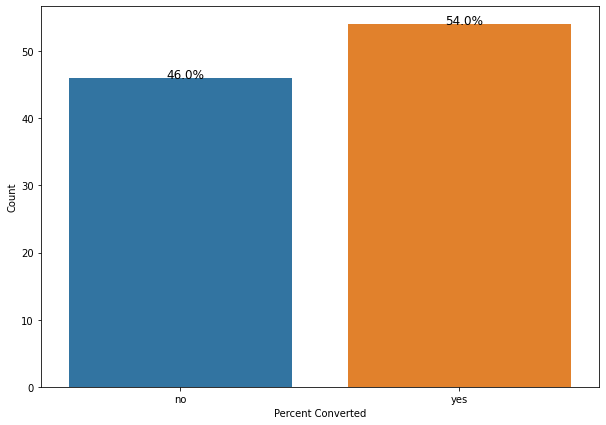

```python
plt.figure(figsize=(10,7))
ax = sns.countplot(abtest['converted'])
plt.xlabel('Percent Converted')
plt.ylabel('Count')
bar_perc(ax,abtest['converted'])
```

54% of all users subscribed

##### Visualization of preferred language

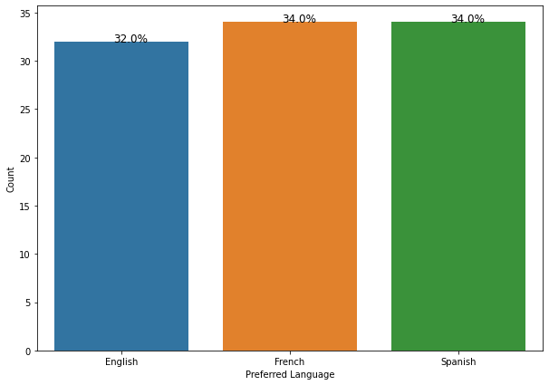

```python
plt.figure(figsize=(10,7))
ax = sns.countplot(abtest['language_preferred'])
plt.xlabel('Preferred Language')
plt.ylabel('Count')
bar_perc(ax,abtest['language_preferred'])
```

As expected, based on value_counts code run earlier

### Bi-variate Analysis

##### Compare conversion rate, separated by which landing page the user saw

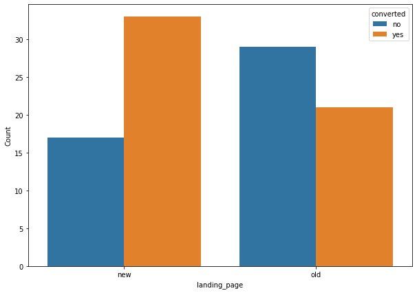

```python
plt.figure(figsize=(10,7))
sns.countplot(abtest['landing_page'], hue=abtest['converted'])
plt.xlabel('landing_page')
plt.ylabel('Count')
plt.show()
```

Observations

- A significantly higher percentage of users converted when shown the new landing page
- More people chose not to subscribe than did when shown the old landing page
- The new landing page appears to be highly successful at converting users to subscribers

# Is the conversion rate for the new page greater than the conversion rate for the old page? It appears to be so - there is a significantly higher rate of conversions for the new page versus the old page. I will perform hypothesis testing later to confirm.

##### Compare time spent, separated by which landing page the user saw

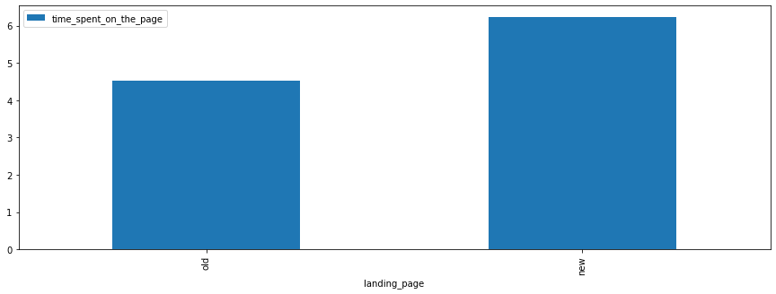

```python
#Use groupby to separate average amount of time spent for old and new
abtest.groupby(by=['landing_page'])['time_spent_on_the_page'].mean().reset_index().sort_values(['time_spent_on_the_page']).tail(10).plot(x='landing_page',
y='time_spent_on_the_page',kind='bar',figsize=(15,5))
plt.show()
```

Observation

- On average, significantly more time was spent on the new landing page than on the old landing page

# Do the users spend more time on the new landing page than the old landing page? It appears so - users spend an average of 6 minutes on the new landing page, compared to an average of 4.5 minutes on the old landing page. I will perform hypothesis testing later to confirm.

##### Compare conversion rate, separated by preferred language

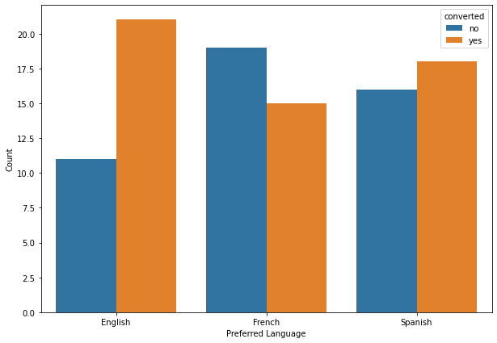

```python
plt.figure(figsize=(10,7))
sns.countplot(abtest['language_preferred'], hue=abtest['converted'])
plt.xlabel('Preferred Language')
plt.ylabel('Count')
plt.show()
```

Observations

- More English speakers converted than did not
- A majority of the French speakers did not convert
- Spanish speakers were about even, although a few more converted than did not

# Does the converted status depend on the preferred language? It appears so - English speakers are most likely to convert, Spanish speakers are an even split, and French speakers are less likely to convert. I will perform hypothesis testing later to confirm.

##### Compare time spent, separated by preferred language

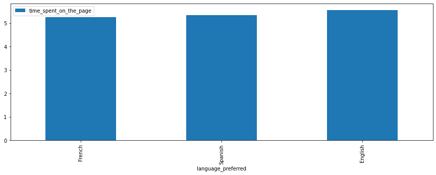

```python
#Use groupby to separate average amount of time spent for the different languages
abtest.groupby(by=['language_preferred'])['time_spent_on_the_page'].mean().reset_index().sort_values(['time_spent_on_the_page']).tail(10).plot(x='language_preferred',
y='time_spent_on_the_page',kind='bar',figsize=(15,5))
plt.show()
```

Observations

- There is no significant difference in the average amount of time spent between the different language preferences

# Is the mean time spent on the page same for the different language users? It appears so - all language users spend an average of around 5 minutes on the page. This graph does not take into account only users who saw the new page, which is the question to be considered. I will need to take additional steps later to fully address the question.

# While I feel I have some preliminary answers from the EDA, I will perform hypothesis testing to be sure.

### Do the users spend more time on the new landing page than the old landing page?

```python
#determine the standard deviations of the samples to determine which hypothesis test to employ
abtest.groupby('landing_page')['time_spent_on_the_page'].std()
```

```
landing_page
new    1.817031
old    2.581975
Name: time_spent_on_the_page, dtype: float64
```

Let 𝜇1 be the average time spent on the old page, and 𝜇2 be the average time spent on the new page.

> $𝐻_0$: 𝜇1 = 𝜇2

> $𝐻_a$: 𝜇1 < 𝜇2

### Are T-test assumptions satisfied?

- Continuous data - Yes, the time spent on page is measured on a continuous scale.
- Normally distributed populations - Yes, populations are assumed to be normal.
- Independent populations - Random samples are from two different groups, so the samples are from two independent populations.
- Unequal population standard deviations - The sample standard deviations are different (see groupby above), so the population standard deviations may be assumed to be different.
- Random sampling from the population - Yes, the collected sample is random.
- I will use a significance level of 0.05

```python
#import the required functions
from scipy.stats import ttest_ind

#create a new dataset with just the times from the old page, and another one with just the times from the new page
old_time = abtest[abtest['landing_page']=='old']['time_spent_on_the_page']
new_time = abtest[abtest['landing_page']=='new']['time_spent_on_the_page']

# find the p-value
test_stat, p_value = ttest_ind(old_time, new_time, equal_var = False)
print('The p-value is ', p_value)
```

```
The p-value is  0.0002784762450333098
```

# Conclusion: since the p-value is significantly less than 0.05, I can reject my null hypothesis. The users spend less time on the old landing page than on the new landing page at a significance level of 0.05

### Is the conversion rate for the new page greater than the conversion rate for the old page?

```python
old_conversion = abtest[abtest['landing_page']=='old']['converted']
new_conversion = abtest[abtest['landing_page']=='new']['converted']
old_conversion.value_counts()
```

```
no     29
yes    21
Name: converted, dtype: int64
```

```python
#21 converted from the old landing page
#how many converted from the new landing page?
new_conversion.value_counts()
```

```
yes    33
no     17
Name: converted, dtype: int64
```

33 converted from the new landing page

### I think we should use the two-proportion z-test. Let's see whether the Z-test assumptions are satisfied or not

- Binomally distributed population - Yes, users either converted, or did not convert
- Random sampling from the population - Yes
- Can the binomial distribution approximated to normal distribution - Yes. Are np and n(1-p) are greater than or equal to 10?

  > $np_1 = 50\cdot \frac{21}{50} =21 \geq 10\\ n(1-p_1) = 50 \cdot \frac{50-21}{50} =29 \geq 10 \\ np_2 = 50 \cdot \frac{33}{50} =33 \geq 10\\ n(1-p_2) = 50 \cdot \frac{50-33}{50} =17 \geq 10 $

> $H_0:p_1 =p_2$

> $H_a:p_1 < p_2$

Significance level will be 0.05.

```python
# import the required function
from statsmodels.stats.proportion import proportions_ztest

# set the counts of conversions
conv = np.array([21, 33])

# set the sample sizes
samp = np.array([50, 50])

# find the p-value
test_stat, p_value = proportions_ztest(conv, samp, alternative = 'smaller')
print('The p-value is ' + str(p_value))
```

```
The p-value is 0.008026308204056278
```

# Conclusion: since p-value is significantly less than 0.05, I will reject my null hypothesis. The conversion rate for the new landing page is higher than the conversion rate for the old landing page at a significance level of 0.05.

### Does the converted status depend on the preferred language?

### I think we should use the Chi-Square test for independence. Let's see whether the assumptions are satisfied or not

- Categorical variables - Yes
- Value of the number of sample observations in each level of the variable is at least 5 - Yes
- Random sampling from the population - Yes

> $H_0:$ Converted status is independent of preferred language

> $H_a:$ Converted status depends on preferred language

Significance level will be 0.05.

##### Next, I will need to create a contingency table

```python
cont_tab = pd.crosstab(index=abtest['language_preferred'], columns=abtest['converted'])
cont_tab
```

| converted language_preferred | no | yes |
| --- | --- | --- |
| English | 11 | 21 |
| French | 19 | 15 |
| Spanish | 16 | 18 |

```python
from scipy.stats import chi2_contingency

# find the p-value
chi, p_value, dof, expected = chi2_contingency(cont_tab)
print('The p-value is', p_value)
```

```
The p-value is 0.2129888748754345
```

# Conclusion: since the p-value is significantly higher than my significance level of 0.05, I can not reject my null hypothesis. We do not have enough statistical significance to conclude that converted status depends on the preferred language of the user at a 0.05 significance level.

### Is the mean time spent on the new page same for the different language users?

Let 𝜇1 = mean amount of time spent on the page for English language users; 𝜇2 = the same for French, and 𝜇3 = the same for Spanish.

> $𝐻_0: 𝜇_1=𝜇_2 \text{ and } 𝜇_1=𝜇_3 \text{ and } 𝜇_2=𝜇_3$

> $𝐻_a: 𝜇_1\neq𝜇_2 \text{ or } 𝜇_1\neq𝜇_3 \text{ or } 𝜇_2\neq𝜇_3$

Significance level is 0.05

```python
#I will create a new dataframe with only users who saw the new page, including time spent and language preferred
new_time = abtest[abtest['landing_page']=='new']['time_spent_on_the_page']
new_lang = abtest[abtest['landing_page']=='new']['language_preferred']
new_time_lang = pd.concat([new_time,new_lang],axis=1,sort=False)
```

```
language_preferred
English    6.663750
French     6.196471
Spanish    5.835294
Name: time_spent_on_the_page, dtype: float64
```

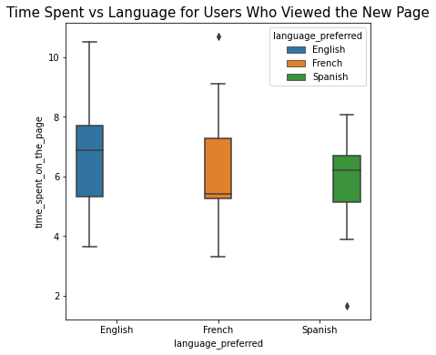

```python
#We need to use the ANOVA test to compare means from more than 2 independent populations.
#First, I will show a box plot of the mean time spent from each language group for users who viewed the new page

print(new_time_lang.groupby("language_preferred")["time_spent_on_the_page"].mean())

# draw the boxplot for visualization
fig, ax = plt.subplots(figsize = (6,6))
a = sns.boxplot(x= "language_preferred", y = 'time_spent_on_the_page' , data = new_time_lang, hue = 'language_preferred')
a.set_title("Time Spent vs Language for Users Who Viewed the New Page", fontsize=15)
plt.show()
```

##### The means appear to be pretty different but are still within 1 minute of each other

##### I will perform a multiple pairwise comparison test (Tukey HSD) to test my hypothesis

```python
from statsmodels.stats.multicomp import pairwise_tukeyhsd

comp = pairwise_tukeyhsd(endog = new_time_lang['time_spent_on_the_page'], groups = new_time_lang['language_preferred'], alpha = 0.05)
print(comp)
```

```
 Multiple Comparison of Means - Tukey HSD, FWER=0.05
=====================================================
 group1  group2 meandiff p-adj   lower  upper  reject
-----------------------------------------------------
English  French  -0.4673 0.7259 -2.0035  1.069  False
English Spanish  -0.8285  0.401 -2.3647 0.7078  False
 French Spanish  -0.3612  0.816  -1.874 1.1516  False
-----------------------------------------------------
```

# Conclusion: the p-values (column p-adj) are all greater than the significance level of 0.05, therefore we can not reject the null hypothesis that all population means are equal. We do not have enough evidence to suggest that the mean amount of time spent on the pages for the different language users is different, at a significance level of 0.05.